# Reglas de Asociación

María Lucía Guastoni

27/3/2021

# 1. Introducción

En el presente trabajo se analizará, mediante reglas de asociación, las característiscas de 8.124 muestras hipotéticas correspondientes a 23 especies de hongos con branquias de las familias Agaricus y Lepiota, en donde cada especie está identificada como comestible o venenosa. Se cuenta con un total de 22 atributos, todas de ellas de clase factor. El objetivo es encontrar reglas de asociación que puedan ser utilizadas para identificar la comestibilidad de una seta.

Para mayor información sobre el set de datos y la descarga de los mismos consultar en:

https://archive.ics.uci.edu/ml/datasets/mushroom

El trabajo se divide en cinco secciones. Después de esta introducción, en la segunda sección, se cargan y se analizan los datos para luego, en la sección tres hallar los itemsets frecuentes. A continuación se buscan reglas de asociación en función de la determinación de distintos valores de diversas variables como soporte y confianza; y finalmente, en la sección 5 se presentan los resultados y conclusiones.

# 2. Carga y análisis de los datos

```r
datos <- read.csv2("../Entrega 1/agaricus-lepiota.data", sep = ",", header = F)
```

Se analiza si existen datos faltantes y la distribución de clases de cada una de las variables:

```r
colSums(is.na(datos))
```

```
 V1  V2  V3  V4  V5  V6  V7  V8  V9 V10 V11 V12 V13 V14 V15 V16 V17 V18 V19 V20
  0   0   0   0   0   0   0   0   0   0   0   0   0   0   0   0   0   0   0   0
V21 V22 V23
  0   0   0
```

```r
lapply(datos, table)
```

```
$V1

   e    p
4208 3916

$V2

   b    c    f    k    s    x
 452    4 3152  828   32 3656

$V3

   f    g    s    y
2320    4 2556 3244

$V4

   b    c    e    g    n    p    r    u    w    y
 168   44 1500 1840 2284  144   16   16 1040 1072

$V5

   f    t
4748 3376

$V6

   a    c    f    l    m    n    p    s    y
 400  192 2160  400   36 3528  256  576  576

$V7

   a    f
 210 7914

$V8

   c    w
6812 1312

```

[output cut: 59 more lines]

```

$V21

   b    h    k    n    o    r    u    w    y
  48 1632 1872 1968   48   72   48 2388   48

$V22

   a    c    n    s    v    y
 384  340  400 1248 4040 1712

$V23

   d    g    l    m    p    u    w
3148 2148  832  292 1144  368  192
```

Se observa que:

- V12 tiene 2480 valores nulos
- V17 toma un único valor, es decir, es una constante, con lo cual no aporta ninguna información y por lo tanto se eliminará.

Luego, se convierte el dataset a formato “transactions”:

```r
data <- dplyr::select(datos, -c(V17))
data <- as(data, "transactions")
str(data)
```

```
Formal class 'transactions' [package "arules"] with 3 slots
  ..@ data       :Formal class 'ngCMatrix' [package "Matrix"] with 5 slots
  .. .. ..@ i       : int [1:178728] 1 7 10 16 23 30 34 35 38 43 ...
  .. .. ..@ p       : int [1:8125] 0 22 44 66 88 110 132 154 176 198 ...
  .. .. ..@ Dim     : int [1:2] 118 8124
  .. .. ..@ Dimnames:List of 2
  .. .. .. ..$ : NULL
  .. .. .. ..$ : NULL
  .. .. ..@ factors : list()
  ..@ itemInfo   :'data.frame': 118 obs. of  3 variables:
  .. ..$ labels   : chr [1:118] "V1=e" "V1=p" "V2=b" "V2=c" ...
  .. ..$ variables: Factor w/ 22 levels "V1","V10","V11",..: 1 1 11 11 11 11 11 11 16 16 ...
  .. ..$ levels   : Factor w/ 23 levels "?","a","b","c",..: 6 15 3 4 7 10 17 22 7 8 ...
  ..@ itemsetInfo:'data.frame': 8124 obs. of  1 variable:
  .. ..$ transactionID: chr [1:8124] "1" "2" "3" "4" ...
```

A continuación se grafica la frecuencia de los items:

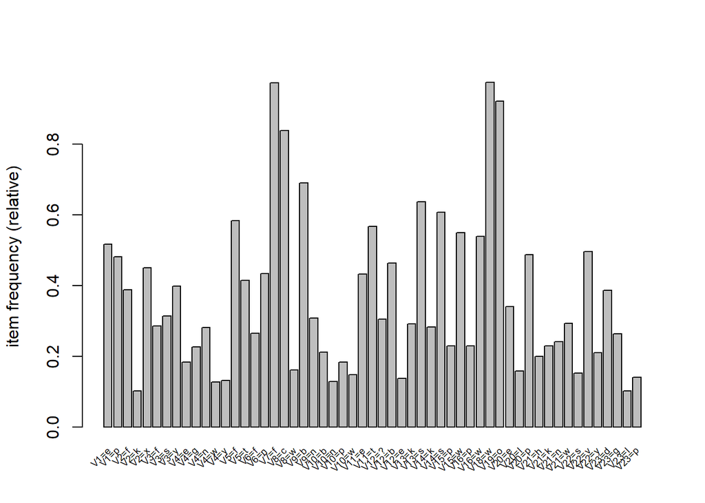

```r
itemFrequencyPlot(data, support = 0.1, cex.names=0.6)
```

En el plot a que sigue se grafican 100 setas aleatoriamente, en donde en el eje de las x se representan las diferentes características y en el eje de la y diferentes observaciones (filas)

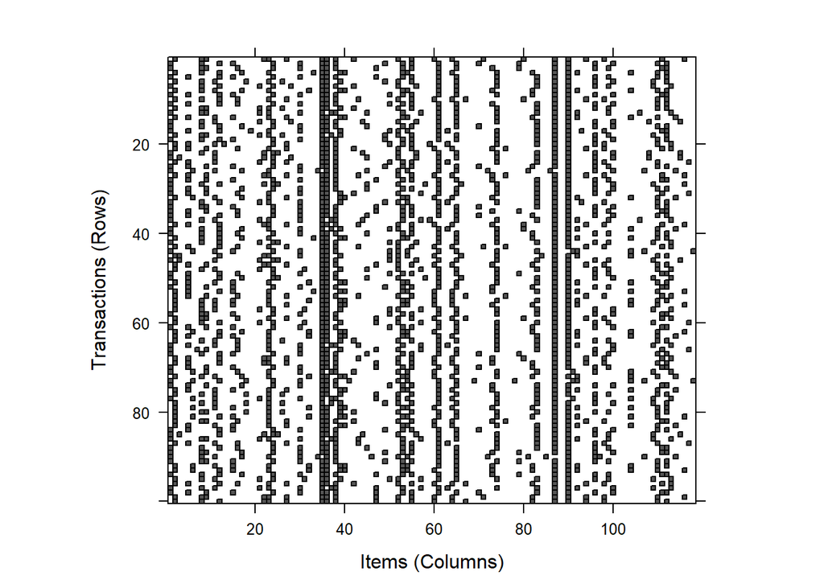

```r
image(sample(data, 100))
```

# 3. Itemsets frecuentes

Se procede a calcular los itemsets frecuentes, realizando diferentes combinaciones de largo máximo y soporte. Se evaluarán 3 máximos distintos: 2, 4 y 10, y en cada uno de ellos se aplicarán soportes diferentes.

### Máximo largo de la reglas: 2

#### Soporte = 0.1

```r
freqitem1 <- eclat(data, parameter=list(supp =0.1, maxlen=2))
```

```
Eclat

parameter specification:
 tidLists support minlen maxlen            target  ext
    FALSE     0.1      1      2 frequent itemsets TRUE

algorithmic control:
 sparse sort verbose
      7   -2    TRUE

Absolute minimum support count: 812

create itemset ...
set transactions ...[118 item(s), 8124 transaction(s)] done [0.01s].
sorting and recoding items ... [55 item(s)] done [0.00s].
creating bit matrix ... [55 row(s), 8124 column(s)] done [0.00s].
writing  ... [763 set(s)] done [0.00s].
Creating S4 object  ... done [0.00s].
```

```r
summary(freqitem1)
```

```
set of 763 itemsets

most frequent items:
  V19=o    V7=f   V18=w    V8=c    V9=b (Other)
     54      53      53      48      45    1218

element (itemset/transaction) length distribution:sizes
  1   2
 55 708

   Min. 1st Qu.  Median    Mean 3rd Qu.    Max.
  1.000   2.000   2.000   1.928   2.000   2.000

summary of quality measures:
    support       transIdenticalToItemsets     count
 Min.   :0.1004   Min.   : 816             Min.   : 816
 1st Qu.:0.1344   1st Qu.:1092             1st Qu.:1092
 Median :0.1960   Median :1592             Median :1592
 Mean   :0.2376   Mean   :1930             Mean   :1930
 3rd Qu.:0.2826   3rd Qu.:2296             3rd Qu.:2296
 Max.   :0.9754   Max.   :7924             Max.   :7924

includes transaction ID lists: FALSE

mining info:
 data ntransactions support
 data          8124     0.1
```

```r
inspect(head(freqitem1))
```

```
    items         support   transIdenticalToItemsets count
[1] {V19=o,V23=l} 0.1024126  832                      832
[2] {V5=f,V23=l}  0.1014279  824                      824
[3] {V4=w,V18=w}  0.1280158 1040                     1040
[4] {V4=w,V7=f}   0.1280158 1040                     1040
[5] {V4=w,V19=o}  0.1073363  872                      872
[6] {V4=w,V15=w}  0.1280158 1040                     1040
```

Con un soporte de 0.1, se generan 763 itemsets frecuentes.

#### Soporte = 0.4

```r
freqitem2 <- eclat(data, parameter=list(supp =0.4, maxlen=2))
```

```
Eclat

parameter specification:
 tidLists support minlen maxlen            target  ext
    FALSE     0.4      1      2 frequent itemsets TRUE

algorithmic control:
 sparse sort verbose
      7   -2    TRUE

Absolute minimum support count: 3249

create itemset ...
set transactions ...[118 item(s), 8124 transaction(s)] done [0.01s].
sorting and recoding items ... [20 item(s)] done [0.00s].
creating bit matrix ... [20 row(s), 8124 column(s)] done [0.00s].
writing  ... [97 set(s)] done [0.00s].
Creating S4 object  ... done [0.00s].
```

```r
summary(freqitem2)
```

```
set of 97 itemsets

most frequent items:
   V7=f   V18=w   V19=o    V8=c    V9=b (Other)
     20      20      17      14      11      92

element (itemset/transaction) length distribution:sizes
 1  2
20 77

   Min. 1st Qu.  Median    Mean 3rd Qu.    Max.
  1.000   2.000   2.000   1.794   2.000   2.000

summary of quality measures:
    support       transIdenticalToItemsets     count
 Min.   :0.4028   Min.   :3272             Min.   :3272
 1st Qu.:0.4357   1st Qu.:3540             1st Qu.:3540
 Median :0.4855   Median :3944             Median :3944
 Mean   :0.5333   Mean   :4333             Mean   :4333
 3rd Qu.:0.5672   3rd Qu.:4608             3rd Qu.:4608
 Max.   :0.9754   Max.   :7924             Max.   :7924

includes transaction ID lists: FALSE

mining info:
 data ntransactions support
 data          8124     0.4
```

```r
inspect(head(freqitem2))
```

```
    items         support   transIdenticalToItemsets count
[1] {V5=t,V18=w}  0.4155588 3376                     3376
[2] {V5=t,V7=f}   0.4155588 3376                     3376
[3] {V5=t,V8=c}   0.4027573 3272                     3272
[4] {V11=e,V18=w} 0.4081733 3316                     3316
[5] {V7=f,V11=e}  0.4069424 3306                     3306
[6] {V6=n,V18=w}  0.4096504 3328                     3328
```

Observamos que con un soporte de 0.4, se tienen 97 itemsets frecuentes, la mayoría de ellos de tamaño 2.

#### Soporte = 0.8

```r
freqitem3 <- eclat(data, parameter=list(supp =0.8, maxlen=2))
```

```
Eclat

parameter specification:
 tidLists support minlen maxlen            target  ext
    FALSE     0.8      1      2 frequent itemsets TRUE

algorithmic control:
 sparse sort verbose
      7   -2    TRUE

Absolute minimum support count: 6499

create itemset ...
set transactions ...[118 item(s), 8124 transaction(s)] done [0.02s].
sorting and recoding items ... [4 item(s)] done [0.00s].
creating bit matrix ... [4 row(s), 8124 column(s)] done [0.00s].
writing  ... [9 set(s)] done [0.00s].
Creating S4 object  ... done [0.00s].
```

```r
summary(freqitem3)
```

```
set of 9 itemsets

most frequent items:
   V7=f   V18=w    V8=c   V19=o    V1=e (Other)
      4       4       3       3       0       0

element (itemset/transaction) length distribution:sizes
1 2
4 5

   Min. 1st Qu.  Median    Mean 3rd Qu.    Max.
  1.000   1.000   2.000   1.556   2.000   2.000

summary of quality measures:
    support       transIdenticalToItemsets     count
 Min.   :0.8127   Min.   :6602             Min.   :6602
 1st Qu.:0.8385   1st Qu.:6812             1st Qu.:6812
 Median :0.8981   Median :7296             Median :7296
 Mean   :0.9006   Mean   :7317             Mean   :7317
 3rd Qu.:0.9732   3rd Qu.:7906             3rd Qu.:7906
 Max.   :0.9754   Max.   :7924             Max.   :7924

includes transaction ID lists: FALSE

mining info:
 data ntransactions support
 data          8124     0.8
```

```r
inspect(freqitem3)
```

```
    items         support   transIdenticalToItemsets count
[1] {V8=c,V18=w}  0.8148695 6620                     6620
[2] {V7=f,V8=c}   0.8126539 6602                     6602
[3] {V18=w,V19=o} 0.8970950 7288                     7288
[4] {V7=f,V19=o}  0.8980798 7296                     7296
[5] {V7=f,V18=w}  0.9731659 7906                     7906
[6] {V18=w}       0.9753816 7924                     7924
[7] {V7=f}        0.9741507 7914                     7914
[8] {V19=o}       0.9217134 7488                     7488
[9] {V8=c}        0.8385032 6812                     6812
```

Exigiendo un soporte de 0.8, se tienen solo 9 itemstes frecuentes, de los cuales 4 de ellos corresponden a un solo item y los restantes 5 a dos.

### Máximo largo de la reglas: 4

#### Soporte = 0.1

```r
freqitem4 <- eclat(data, parameter=list(supp =0.1, maxlen=4))
```

```
Eclat

parameter specification:
 tidLists support minlen maxlen            target  ext
    FALSE     0.1      1      4 frequent itemsets TRUE

algorithmic control:
 sparse sort verbose
      7   -2    TRUE

Absolute minimum support count: 812

create itemset ...
set transactions ...[118 item(s), 8124 transaction(s)] done [0.01s].
sorting and recoding items ... [55 item(s)] done [0.00s].
creating bit matrix ... [55 row(s), 8124 column(s)] done [0.00s].
writing  ... [16913 set(s)] done [0.01s].
Creating S4 object  ... done [0.00s].
```

```r
summary(freqitem4)
```

```
set of 16913 itemsets

most frequent items:
   V7=f   V18=w   V19=o    V8=c   V11=t (Other)
   3898    3898    3738    3395    2689   44568

element (itemset/transaction) length distribution:sizes
    1     2     3     4
   55   708  3885 12265

   Min. 1st Qu.  Median    Mean 3rd Qu.    Max.
  1.000   3.000   4.000   3.677   4.000   4.000

summary of quality measures:
    support       transIdenticalToItemsets     count
 Min.   :0.1002   Min.   : 814             Min.   : 814
 1st Qu.:0.1083   1st Qu.: 880             1st Qu.: 880
 Median :0.1329   Median :1080             Median :1080
 Mean   :0.1615   Mean   :1312             Mean   :1312
 3rd Qu.:0.1950   3rd Qu.:1584             3rd Qu.:1584
 Max.   :0.9754   Max.   :7924             Max.   :7924

includes transaction ID lists: FALSE

mining info:
 data ntransactions support
 data          8124     0.1
```

```r
inspect(head(freqitem4))
```

```
    items                    support   transIdenticalToItemsets count
[1] {V5=f,V19=o,V23=l}       0.1014279  824                      824
[2] {V19=o,V23=l}            0.1024126  832                      832
[3] {V5=f,V23=l}             0.1014279  824                      824
[4] {V4=w,V15=w,V16=w,V18=w} 0.1280158 1040                     1040
[5] {V4=w,V7=f,V15=w,V16=w}  0.1280158 1040                     1040
[6] {V4=w,V15=w,V16=w,V19=o} 0.1073363  872                      872
```

Se observa que se han generado un total de 16.913 itemsets, de los cuales el 72.52 son de tamaño 4.

Puede verse que la característica más frecuente es “gill-attachment” = free, a la par con “veil-color” = white.

#### Soporte = 0.2

```r
freqitem5 <- eclat(data, parameter=list(supp =0.2, maxlen=4))
```

```
Eclat

parameter specification:
 tidLists support minlen maxlen            target  ext
    FALSE     0.2      1      4 frequent itemsets TRUE

algorithmic control:
 sparse sort verbose
      7   -2    TRUE

Absolute minimum support count: 1624

create itemset ...
set transactions ...[118 item(s), 8124 transaction(s)] done [0.01s].
sorting and recoding items ... [42 item(s)] done [0.00s].
creating bit matrix ... [42 row(s), 8124 column(s)] done [0.00s].
writing  ... [3935 set(s)] done [0.00s].
Creating S4 object  ... done [0.00s].
```

```r
summary(freqitem5)
```

```
set of 3935 itemsets

most frequent items:
  V18=w    V7=f   V19=o    V8=c   V11=t (Other)
   1169    1168    1108     982     772    8609

element (itemset/transaction) length distribution:sizes
   1    2    3    4
  42  334 1138 2421

   Min. 1st Qu.  Median    Mean 3rd Qu.    Max.
  1.000   3.000   4.000   3.509   4.000   4.000

summary of quality measures:
    support       transIdenticalToItemsets     count
 Min.   :0.2001   Min.   :1626             Min.   :1626
 1st Qu.:0.2127   1st Qu.:1728             1st Qu.:1728
 Median :0.2334   Median :1896             Median :1896
 Mean   :0.2672   Mean   :2170             Mean   :2170
 3rd Qu.:0.2846   3rd Qu.:2312             3rd Qu.:2312
 Max.   :0.9754   Max.   :7924             Max.   :7924

includes transaction ID lists: FALSE

mining info:
 data ntransactions support
 data          8124     0.2
```

```r
inspect(head(freqitem5))
```

```
    items                    support   transIdenticalToItemsets count
[1] {V8=c,V18=w,V19=o,V21=h} 0.2008863 1632                     1632
[2] {V7=f,V8=c,V19=o,V21=h}  0.2008863 1632                     1632
[3] {V7=f,V8=c,V18=w,V21=h}  0.2008863 1632                     1632
[4] {V8=c,V18=w,V21=h}       0.2008863 1632                     1632
[5] {V7=f,V8=c,V21=h}        0.2008863 1632                     1632
[6] {V8=c,V19=o,V21=h}       0.2008863 1632                     1632
```

Puede verse que en este caso, en comparación con el anterior, el número de itemserts frecuentes disminuye notablemente, a 3.935, con un 61.52 de itemsets de largo = 4.

#### Soporte = 0.5

```r
freqitem6 <- eclat(data, parameter=list(supp =0.5, maxlen=4))
```

```
Eclat

parameter specification:
 tidLists support minlen maxlen            target  ext
    FALSE     0.5      1      4 frequent itemsets TRUE

algorithmic control:
 sparse sort verbose
      7   -2    TRUE

Absolute minimum support count: 4062

create itemset ...
set transactions ...[118 item(s), 8124 transaction(s)] done [0.01s].
sorting and recoding items ... [12 item(s)] done [0.00s].
creating bit matrix ... [12 row(s), 8124 column(s)] done [0.00s].
writing  ... [76 set(s)] done [0.00s].
Creating S4 object  ... done [0.00s].
```

```r
summary(freqitem6)
```

```
set of 76 itemsets

most frequent items:
   V7=f   V18=w   V19=o    V8=c   V13=s (Other)
     36      36      30      19      14      48

element (itemset/transaction) length distribution:sizes
 1  2  3  4
12 29 27  8

   Min. 1st Qu.  Median    Mean 3rd Qu.    Max.
  1.000   2.000   2.000   2.408   3.000   4.000

summary of quality measures:
    support       transIdenticalToItemsets     count
 Min.   :0.5081   Min.   :4128             Min.   :4128
 1st Qu.:0.5396   1st Qu.:4384             1st Qu.:4384
 Median :0.5672   Median :4608             Median :4608
 Mean   :0.6228   Mean   :5060             Mean   :5060
 3rd Qu.:0.6441   3rd Qu.:5232             3rd Qu.:5232
 Max.   :0.9754   Max.   :7924             Max.   :7924

includes transaction ID lists: FALSE

mining info:
 data ntransactions support
 data          8124     0.5
```

```r
inspect(head(freqitem6))
```

```
    items              support   transIdenticalToItemsets count
[1] {V7=f,V16=w,V18=w} 0.5396356 4384                     4384
[2] {V16=w,V18=w}      0.5396356 4384                     4384
[3] {V7=f,V16=w}       0.5396356 4384                     4384
[4] {V7=f,V15=w,V18=w} 0.5494830 4464                     4464
[5] {V15=w,V18=w}      0.5494830 4464                     4464
[6] {V7=f,V15=w}       0.5494830 4464                     4464
```

### Máximo largo de la reglas: 10

#### Soporte = 0.3

```r
freqitem7 <- eclat(data, parameter=list(supp =0.3, maxlen=10))
```

```
Eclat

parameter specification:
 tidLists support minlen maxlen            target  ext
    FALSE     0.3      1     10 frequent itemsets TRUE

algorithmic control:
 sparse sort verbose
      7   -2    TRUE

Absolute minimum support count: 2437

create itemset ...
set transactions ...[118 item(s), 8124 transaction(s)] done [0.01s].
sorting and recoding items ... [27 item(s)] done [0.00s].
creating bit matrix ... [27 row(s), 8124 column(s)] done [0.00s].
writing  ... [1367 set(s)] done [0.00s].
Creating S4 object  ... done [0.00s].
```

```r
summary(freqitem7)
```

```
set of 1367 itemsets

most frequent items:
   V7=f   V18=w   V19=o    V8=c   V13=s (Other)
    666     666     554     514     443    2647

element (itemset/transaction) length distribution:sizes
  1   2   3   4   5   6   7   8
 27 136 319 406 306 135  34   4

   Min. 1st Qu.  Median    Mean 3rd Qu.    Max.
  1.000   3.000   4.000   4.016   5.000   8.000

summary of quality measures:
    support       transIdenticalToItemsets     count
 Min.   :0.3003   Min.   :2440             Min.   :2440
 1st Qu.:0.3171   1st Qu.:2576             1st Qu.:2576
 Median :0.3407   Median :2768             Median :2768
 Mean   :0.3685   Mean   :2993             Mean   :2993
 3rd Qu.:0.3919   3rd Qu.:3184             3rd Qu.:3184
 Max.   :0.9754   Max.   :7924             Max.   :7924

includes transaction ID lists: FALSE

mining info:
 data ntransactions support
 data          8124     0.3
```

```r
inspect(head(freqitem7))
```

```
    items                   support   transIdenticalToItemsets count
[1] {V7=f,V9=n,V18=w,V19=o} 0.3082226 2504                     2504
[2] {V9=n,V18=w,V19=o}      0.3082226 2504                     2504
[3] {V7=f,V9=n,V19=o}       0.3092073 2512                     2512
[4] {V7=f,V9=n,V18=w}       0.3082226 2504                     2504
[5] {V9=n,V18=w}            0.3082226 2504                     2504
[6] {V7=f,V9=n}             0.3092073 2512                     2512
```

Vemos que un soporte de 0.3 sólo hay itemsets con un tamaño máximo de 8, aunque la mayoría de los mismos son de tamaño 4.

#### Soporte = 0.5

```r
freqitem8 <- eclat(data, parameter=list(supp =0.5, maxlen=10))
```

```
Eclat

parameter specification:
 tidLists support minlen maxlen            target  ext
    FALSE     0.5      1     10 frequent itemsets TRUE

algorithmic control:
 sparse sort verbose
      7   -2    TRUE

Absolute minimum support count: 4062

create itemset ...
set transactions ...[118 item(s), 8124 transaction(s)] done [0.01s].
sorting and recoding items ... [12 item(s)] done [0.00s].
creating bit matrix ... [12 row(s), 8124 column(s)] done [0.00s].
writing  ... [76 set(s)] done [0.00s].
Creating S4 object  ... done [0.00s].
```

```r
summary(freqitem8)
```

```
set of 76 itemsets

most frequent items:
   V7=f   V18=w   V19=o    V8=c   V13=s (Other)
     36      36      30      19      14      48

element (itemset/transaction) length distribution:sizes
 1  2  3  4
12 29 27  8

   Min. 1st Qu.  Median    Mean 3rd Qu.    Max.
  1.000   2.000   2.000   2.408   3.000   4.000

summary of quality measures:
    support       transIdenticalToItemsets     count
 Min.   :0.5081   Min.   :4128             Min.   :4128
 1st Qu.:0.5396   1st Qu.:4384             1st Qu.:4384
 Median :0.5672   Median :4608             Median :4608
 Mean   :0.6228   Mean   :5060             Mean   :5060
 3rd Qu.:0.6441   3rd Qu.:5232             3rd Qu.:5232
 Max.   :0.9754   Max.   :7924             Max.   :7924

includes transaction ID lists: FALSE

mining info:
 data ntransactions support
 data          8124     0.5
```

```r
inspect(head(freqitem8))
```

```
    items              support   transIdenticalToItemsets count
[1] {V7=f,V16=w,V18=w} 0.5396356 4384                     4384
[2] {V16=w,V18=w}      0.5396356 4384                     4384
[3] {V7=f,V16=w}       0.5396356 4384                     4384
[4] {V7=f,V15=w,V18=w} 0.5494830 4464                     4464
[5] {V15=w,V18=w}      0.5494830 4464                     4464
[6] {V7=f,V15=w}       0.5494830 4464                     4464
```

Se observa que los resultados de la búsqueda de itemsets con soporte 0.5 y largo máximo de 10 arroja los mismos resultados que el modelo 3, con igual soporte pero con maxlen = 4. Por lo tanto, se observa que para este soporte el máximo de itemsets es de 4.

#### Soporte = 0.8

```r
freqitem9 <- eclat(data, parameter=list(supp =0.8, maxlen=10))
```

```
Eclat

parameter specification:
 tidLists support minlen maxlen            target  ext
    FALSE     0.8      1     10 frequent itemsets TRUE

algorithmic control:
 sparse sort verbose
      7   -2    TRUE

Absolute minimum support count: 6499

create itemset ...
set transactions ...[118 item(s), 8124 transaction(s)] done [0.01s].
sorting and recoding items ... [4 item(s)] done [0.00s].
creating bit matrix ... [4 row(s), 8124 column(s)] done [0.00s].
writing  ... [11 set(s)] done [0.00s].
Creating S4 object  ... done [0.00s].
```

```r
summary(freqitem9)
```

```
set of 11 itemsets

most frequent items:
   V7=f   V18=w    V8=c   V19=o    V1=e (Other)
      6       6       4       4       0       0

element (itemset/transaction) length distribution:sizes
1 2 3
4 5 2

   Min. 1st Qu.  Median    Mean 3rd Qu.    Max.
  1.000   1.000   2.000   1.818   2.000   3.000

summary of quality measures:
    support       transIdenticalToItemsets     count
 Min.   :0.8127   Min.   :6602             Min.   :6602
 1st Qu.:0.8267   1st Qu.:6716             1st Qu.:6716
 Median :0.8971   Median :7288             Median :7288
 Mean   :0.8923   Mean   :7249             Mean   :7249
 3rd Qu.:0.9474   3rd Qu.:7697             3rd Qu.:7697
 Max.   :0.9754   Max.   :7924             Max.   :7924

includes transaction ID lists: FALSE

mining info:
 data ntransactions support
 data          8124     0.8
```

```r
inspect(freqitem9)
```

```
     items              support   transIdenticalToItemsets count
[1]  {V7=f,V8=c,V18=w}  0.8126539 6602                     6602
[2]  {V8=c,V18=w}       0.8148695 6620                     6620
[3]  {V7=f,V8=c}        0.8126539 6602                     6602
[4]  {V7=f,V18=w,V19=o} 0.8970950 7288                     7288
[5]  {V18=w,V19=o}      0.8970950 7288                     7288
[6]  {V7=f,V19=o}       0.8980798 7296                     7296
[7]  {V7=f,V18=w}       0.9731659 7906                     7906
[8]  {V18=w}            0.9753816 7924                     7924
[9]  {V7=f}             0.9741507 7914                     7914
[10] {V19=o}            0.9217134 7488                     7488
[11] {V8=c}             0.8385032 6812                     6812
```

En este caso se observa que hay 11 itemsets frecuentes, dos más que en el caso de mismo soporte pero con un maxlen de 2. Estos dos itemsets de diferencia son de tamaño 3.

# 4. Reglas de asociación

En el presente apartado se buscarán reglas de asociación en algunos de los itemsets frecuentes identificados en la sección anterior, de los cuales se elegirá un modelo de cada tamaño de itemset.

## Tamaño de itemset = 2

### Confianza = 0.7 y Soporte = 0.1

```r
AR_1 <- ruleInduction(freqitem1, confidence = .7)
inspect(head(AR_1))
```

```
    lhs        rhs     support   confidence lift
[1] {V23=l} => {V19=o} 0.1024126 1.0000000  1.084936
[2] {V23=l} => {V5=f}  0.1014279 0.9903846  1.694584
[3] {V4=w}  => {V18=w} 0.1280158 1.0000000  1.025240
[4] {V4=w}  => {V7=f}  0.1280158 1.0000000  1.026535
[5] {V4=w}  => {V19=o} 0.1073363 0.8384615  0.909677
[6] {V4=w}  => {V15=w} 0.1280158 1.0000000  1.819892
```

```r
AR_1_e <- sort(subset(AR_1, subset = rhs %in% "V1=e"), by="confidence", decreasing=TRUE)
```

```r
dim(inspect(AR_1_e[is.redundant(AR_1_e)]))[1]
```

Se confirma que ninguna de las 11 reglas es redundante.

Puede observarse que con un soporte de 0.1, el valor máximo de confianza que se logra es de 0.96.

También se filtran, para todas las pruebas, las reglas relevantes para setas venenosas.

```r
dim(inspect(subset(AR_1, subset = rhs %in% "V1=p")))
```

```
     lhs        rhs    support   confidence lift
[1]  {V23=p} => {V1=p} 0.1240768 0.8811189  1.827939
[2]  {V20=l} => {V1=p} 0.1595273 1.0000000  2.074566
[3]  {V21=h} => {V1=p} 0.1949778 0.9705882  2.013549
[4]  {V10=b} => {V1=p} 0.2127031 1.0000000  2.074566
[5]  {V6=f}  => {V1=p} 0.2658789 1.0000000  2.074566
[6]  {V14=k} => {V1=p} 0.2658789 0.9375000  1.944906
[7]  {V13=k} => {V1=p} 0.2742491 0.9392917  1.948623
[8]  {V21=w} => {V1=p} 0.2230428 0.7587940  1.574168
[9]  {V12=?} => {V1=p} 0.2166420 0.7096774  1.472273
[10] {V9=n}  => {V1=p} 0.2737568 0.8853503  1.836718
[11] {V22=v} => {V1=p} 0.3505662 0.7049505  1.462466
```

```
[1] 11  6
```

```r
AR_1_p <- sort(subset(AR_1, subset = rhs %in% "V1=p"), by="confidence", decreasing=TRUE)
inspect(AR_1_p)
```

```
     lhs        rhs    support   confidence lift
[1]  {V20=l} => {V1=p} 0.1595273 1.0000000  2.074566
[2]  {V10=b} => {V1=p} 0.2127031 1.0000000  2.074566
[3]  {V6=f}  => {V1=p} 0.2658789 1.0000000  2.074566
[4]  {V21=h} => {V1=p} 0.1949778 0.9705882  2.013549
[5]  {V13=k} => {V1=p} 0.2742491 0.9392917  1.948623
[6]  {V14=k} => {V1=p} 0.2658789 0.9375000  1.944906
[7]  {V9=n}  => {V1=p} 0.2737568 0.8853503  1.836718
[8]  {V23=p} => {V1=p} 0.1240768 0.8811189  1.827939
[9]  {V21=w} => {V1=p} 0.2230428 0.7587940  1.574168
[10] {V12=?} => {V1=p} 0.2166420 0.7096774  1.472273
[11] {V22=v} => {V1=p} 0.3505662 0.7049505  1.462466
```

### Confianza = 0.7 y Soporte = 0.4

Se evalúa a continuación aumentar el soporte a 0.4:

```r
AR_2 <- ruleInduction(freqitem2, confidence = .7)
AR_2
```

```
set of 87 rules
```

```r
AR_2_e <- sort(subset(AR_2, subset = rhs %in% "V1=e"), by="confidence", decreasing=TRUE)
summary(AR_2_e)
```

```
set of 2 rules

rule length distribution (lhs + rhs):sizes
2
2

   Min. 1st Qu.  Median    Mean 3rd Qu.    Max.
      2       2       2       2       2       2

summary of quality measures:
    support         confidence          lift
 Min.   :0.4195   Min.   :0.7032   Min.   :1.358
 1st Qu.:0.4266   1st Qu.:0.7689   1st Qu.:1.485
 Median :0.4338   Median :0.8346   Median :1.611
 Mean   :0.4338   Mean   :0.8346   Mean   :1.611
 3rd Qu.:0.4409   3rd Qu.:0.9003   3rd Qu.:1.738
 Max.   :0.4481   Max.   :0.9660   Max.   :1.865
```

```r
inspect(head(AR_2_e))
```

```
    lhs        rhs    support   confidence lift
[1] {V6=n}  => {V1=e} 0.4194978 0.9659864  1.864941
[2] {V13=s} => {V1=e} 0.4480551 0.7032457  1.357692
```

Quizás disminuyendo la confianza se logra mayor cantidad de reglas.

```r
dim(inspect(subset(AR_2, subset = rhs %in% "V1=p")))
```

### Confianza = 0.5 y Soporte = 0.4

```r
AR_3 <- ruleInduction(freqitem2, confidence = .5)
AR_3
```

```
set of 133 rules
```

```r
AR_3_e <- sort(subset(AR_3, subset = rhs %in% "V1=e"), by="confidence", decreasing=TRUE)
summary(AR_3_e)
```

```
set of 6 rules

rule length distribution (lhs + rhs):sizes
2
6

   Min. 1st Qu.  Median    Mean 3rd Qu.    Max.
      2       2       2       2       2       2

summary of quality measures:
    support         confidence          lift
 Min.   :0.4185   Min.   :0.5068   Min.   :0.9785
 1st Qu.:0.4266   1st Qu.:0.5528   1st Qu.:1.0672
 Median :0.4653   Median :0.6937   Median :1.3392
 Mean   :0.4595   Mean   :0.6785   Mean   :1.3099
 3rd Qu.:0.4914   3rd Qu.:0.7021   3rd Qu.:1.3554
 Max.   :0.4943   Max.   :0.9660   Max.   :1.8649
```

```r
inspect(head(AR_3_e))
```

```
    lhs        rhs    support   confidence lift
[1] {V6=n}  => {V1=e} 0.4194978 0.9659864  1.8649414
[2] {V13=s} => {V1=e} 0.4480551 0.7032457  1.3576921
[3] {V9=b}  => {V1=e} 0.4825209 0.6985032  1.3485361
[4] {V14=s} => {V1=e} 0.4185130 0.6888169  1.3298356
[5] {V7=f}  => {V1=e} 0.4943378 0.5074551  0.9796971
[6] {V18=w} => {V1=e} 0.4943378 0.5068147  0.9784608
```

```r
dim(inspect(AR_3_e[is.redundant(AR_3_e)]))[1]
```

De las 133 reglas con soporte = 0.4 y confianza = 0.5, 6 de ellas son relevantes para edibility, y ninguna es redundante.

```r
dim(inspect(subset(AR_3, subset = rhs %in% "V1=p")))
```

```
    lhs        rhs    support   confidence lift
[1] {V19=o} => {V1=p} 0.4687346 0.5085470  1.055014
[2] {V8=c}  => {V1=p} 0.4682422 0.5584263  1.158492
[3] {V5=f}  => {V1=p} 0.4052191 0.6933446  1.438389
```

```
[1] 3 6
```

```r
AR_3_p <- sort(subset(AR_1, subset = rhs %in% "V1=p"), by="confidence", decreasing=TRUE)
inspect(head(AR_3_p))
```

```
    lhs        rhs    support   confidence lift
[1] {V20=l} => {V1=p} 0.1595273 1.0000000  2.074566
[2] {V10=b} => {V1=p} 0.2127031 1.0000000  2.074566
[3] {V6=f}  => {V1=p} 0.2658789 1.0000000  2.074566
[4] {V21=h} => {V1=p} 0.1949778 0.9705882  2.013549
[5] {V13=k} => {V1=p} 0.2742491 0.9392917  1.948623
[6] {V14=k} => {V1=p} 0.2658789 0.9375000  1.944906
```

## Tamaño de itemset = 4

### Confianza = 0.7 y Soporte = 0.2

```r
AR_4 <- ruleInduction(freqitem5, confidence = .7)
AR_4_e <- sort(subset(AR_4, subset = rhs %in% "V1=e"), by="confidence", decreasing=TRUE)
summary(AR_4_e)
```

```
set of 325 rules

rule length distribution (lhs + rhs):sizes
  2   3   4
  6  57 262

   Min. 1st Qu.  Median    Mean 3rd Qu.    Max.
  2.000   4.000   4.000   3.788   4.000   4.000

summary of quality measures:
    support         confidence          lift
 Min.   :0.2029   Min.   :0.7032   Min.   :1.358
 1st Qu.:0.2196   1st Qu.:0.8197   1st Qu.:1.583
 Median :0.2314   Median :0.8833   Median :1.705
 Mean   :0.2661   Mean   :0.8881   Mean   :1.715
 3rd Qu.:0.3151   3rd Qu.:0.9610   3rd Qu.:1.855
 Max.   :0.4481   Max.   :1.0000   Max.   :1.931
```

```r
AR_4_e.pruned <- AR_4_e[!is.redundant(AR_4_e)]
inspect(head(AR_4_e.pruned))
```

```
    lhs                   rhs    support   confidence lift
[1] {V9=b,V21=n}       => {V1=e} 0.2028557 1          1.930608
[2] {V5=t,V23=d}       => {V1=e} 0.2245199 1          1.930608
[3] {V6=n,V12=b,V23=d} => {V1=e} 0.2136878 1          1.930608
[4] {V6=n,V20=p,V23=d} => {V1=e} 0.2136878 1          1.930608
[5] {V6=n,V9=b,V23=d}  => {V1=e} 0.2136878 1          1.930608
[6] {V6=n,V13=s,V23=d} => {V1=e} 0.2186115 1          1.930608
```

Vemos que existen 325 relgas de asociación relevantes para edibility, de las cuales 219 son redundantes, con lo cual quedarían 106 reglas netas.

```r
AR_4_p <- sort(subset(AR_1, subset = rhs %in% "V1=p"), by="confidence", decreasing=TRUE)
inspect(head(AR_4_p))
```

```
    lhs        rhs    support   confidence lift
[1] {V20=l} => {V1=p} 0.1595273 1.0000000  2.074566
[2] {V10=b} => {V1=p} 0.2127031 1.0000000  2.074566
[3] {V6=f}  => {V1=p} 0.2658789 1.0000000  2.074566
[4] {V21=h} => {V1=p} 0.1949778 0.9705882  2.013549
[5] {V13=k} => {V1=p} 0.2742491 0.9392917  1.948623
[6] {V14=k} => {V1=p} 0.2658789 0.9375000  1.944906
```

### Confianza = 0.7 y Soporte = 0.5

```r
AR_5 <- ruleInduction(freqitem6, confidence = .7)
dim(inspect(subset(AR_5, subset = rhs %in% "V1=e")))
```

```r
dim(inspect(subset(AR_5, subset = rhs %in% "V1=p")))
```

Se observa que no existen reglas relevantes para edibility ni para poisonous bajo los parámetros seleccionados. Se evaluará disminuir la confianza a 0.5.

### Confianza = 0.5 y Soporte = 0.5

```r
AR_6 <- ruleInduction(freqitem6, confidence = .5)
summary(AR_6)
```

```
set of 171 rules

rule length distribution (lhs + rhs):sizes
 2  3  4
58 81 32

   Min. 1st Qu.  Median    Mean 3rd Qu.    Max.
  2.000   2.000   3.000   2.848   3.000   4.000

summary of quality measures:
    support         confidence          lift
 Min.   :0.5081   Min.   :0.5533   Min.   :0.9424
 1st Qu.:0.5350   1st Qu.:0.6564   1st Qu.:0.9855
 Median :0.5598   Median :0.9218   Median :1.0061
 Mean   :0.6026   Mean   :0.8465   Mean   :1.0097
 3rd Qu.:0.6125   3rd Qu.:0.9979   3rd Qu.:1.0252
 Max.   :0.9732   Max.   :1.0000   Max.   :1.3215
```

```r
dim(inspect(subset(AR_6, subset = rhs %in% "V1=e")))
```

```r
dim(inspect(subset(AR_6, subset = rhs %in% "V1=p")))
```

Tampoco existen reglas de asociación con una confianza de 0.5 y un soporte de 0.5 relevantes para la variable target.

## Tamaño de itemset = 10

### Confianza = 0.7 y Soporte = 0.3

```r
AR_7 <- ruleInduction(freqitem7, confidence = .7)
AR_7_e <- sort(subset(AR_7, subset = rhs %in% "V1=e"), by="confidence", decreasing=TRUE)
AR_7_e.pruned <- AR_7_e[!is.redundant(AR_7_e)]
inspect(head(AR_7_e.pruned))
```

```
    lhs                   rhs    support   confidence lift
[1] {V6=n,V9=b,V19=o}  => {V1=e} 0.3308715 1.0000000  1.930608
[2] {V6=n,V11=t}       => {V1=e} 0.3072378 1.0000000  1.930608
[3] {V6=n,V13=s,V19=o} => {V1=e} 0.3042836 0.9967742  1.924381
[4] {V6=n,V18=w,V19=o} => {V1=e} 0.3308715 0.9853372  1.902300
[5] {V6=n,V19=o}       => {V1=e} 0.3545052 0.9836066  1.898959
[6] {V6=n,V9=b}        => {V1=e} 0.3958641 0.9781022  1.888332
```

De las 296 reglas relevantes para edibility, 251 de ellas son redundates. Luego de eliminarlas, quedan 45 reglas de asociación.

Se extraen las reglas relevantes para las setas venenosas:

```r
dim(subset(AR_7, subset = rhs %in% "V1=p"))[1]
```

```r
AR_7_p <- sort(subset(AR_1, subset = rhs %in% "V1=p"), by="confidence", decreasing=TRUE)
inspect(head(AR_7_p))
```

```
    lhs        rhs    support   confidence lift
[1] {V20=l} => {V1=p} 0.1595273 1.0000000  2.074566
[2] {V10=b} => {V1=p} 0.2127031 1.0000000  2.074566
[3] {V6=f}  => {V1=p} 0.2658789 1.0000000  2.074566
[4] {V21=h} => {V1=p} 0.1949778 0.9705882  2.013549
[5] {V13=k} => {V1=p} 0.2742491 0.9392917  1.948623
[6] {V14=k} => {V1=p} 0.2658789 0.9375000  1.944906
```

### Confianza = 0.7 y Soporte = 0.5

```r
AR_8 <- ruleInduction(freqitem8, confidence = .7)
dim(inspect(subset(AR_8, subset = rhs %in% "V1=e")))
```

```r
dim(subset(AR_8, subset = rhs %in% "V1=p"))
```

### Confianza = 0.3 y Soporte = 0.5

```r
AR_9 <- ruleInduction(freqitem8, confidence = .3)
dim(inspect(subset(AR_9, subset = rhs %in% "V1=p")))
```

Tampoco en este caso hay reglas de asociación para la combinación de parámetros especificados.

Con todas las pruebas realizadas, se procederá a analizar cuáles son las características de los hongos comestibles y de los venenosos.

# 5. Resultados y conclusiones

Para analizar los resultados obtenidos, se juntaran todas las reglas relativas a cada uno de los dos posibles valores de la variable target: setas comestibles versus setas venenosas, generando así dos tablas.

```r
resultados_e <- c(AR_1_e, AR_2_e, AR_3_e, AR_4_e.pruned, AR_7_e.pruned)
resultados_e <- resultados_e[!duplicated(resultados_e)]
resultados_e <- sort(resultados_e, by = "lift", decreasing = T)
summary(resultados_e)
```

```
set of 121 rules

rule length distribution (lhs + rhs):sizes
 2  3  4  5  6
15 37 63  5  1

   Min. 1st Qu.  Median    Mean 3rd Qu.    Max.
  2.000   3.000   4.000   3.504   4.000   6.000

summary of quality measures:
    support         confidence          lift
 Min.   :0.1064   Min.   :0.5068   Min.   :0.9785
 1st Qu.:0.2186   1st Qu.:0.8188   1st Qu.:1.5808
 Median :0.2304   Median :0.8725   Median :1.6845
 Mean   :0.2740   Mean   :0.8767   Mean   :1.6925
 3rd Qu.:0.3309   3rd Qu.:0.9660   3rd Qu.:1.8649
 Max.   :0.4943   Max.   :1.0000   Max.   :1.9306
```

```r
resultados_e_10 <- head(resultados_e, 10)
inspect(resultados_e_10)
```

```
     lhs                    rhs    support   confidence lift
[1]  {V9=b,V21=n}        => {V1=e} 0.2028557 1          1.930608
[2]  {V5=t,V23=d}        => {V1=e} 0.2245199 1          1.930608
[3]  {V6=n,V12=b,V23=d}  => {V1=e} 0.2136878 1          1.930608
[4]  {V6=n,V20=p,V23=d}  => {V1=e} 0.2136878 1          1.930608
[5]  {V6=n,V9=b,V23=d}   => {V1=e} 0.2136878 1          1.930608
[6]  {V6=n,V13=s,V23=d}  => {V1=e} 0.2186115 1          1.930608
[7]  {V6=n,V14=s,V23=d}  => {V1=e} 0.2127031 1          1.930608
[8]  {V11=t,V12=b,V23=d} => {V1=e} 0.2245199 1          1.930608
[9]  {V9=b,V20=p,V23=d}  => {V1=e} 0.2136878 1          1.930608
[10] {V11=t,V20=p,V23=d} => {V1=e} 0.2245199 1          1.930608
```

```r
resultados_p <- c(AR_1_p, AR_3_p, AR_4_p, AR_7_p)
resultados_p <- resultados_p[!duplicated(resultados_p)]
resultados_p <- sort(resultados_p, by = "lift", decreasing = T)
summary(resultados_p)
```

```
set of 11 rules

rule length distribution (lhs + rhs):sizes
 2
11

   Min. 1st Qu.  Median    Mean 3rd Qu.    Max.
      2       2       2       2       2       2

summary of quality measures:
    support         confidence          lift
 Min.   :0.1241   Min.   :0.7050   Min.   :1.462
 1st Qu.:0.2038   1st Qu.:0.8200   1st Qu.:1.701
 Median :0.2230   Median :0.9375   Median :1.945
 Mean   :0.2328   Mean   :0.8898   Mean   :1.846
 3rd Qu.:0.2698   3rd Qu.:0.9853   3rd Qu.:2.044
 Max.   :0.3506   Max.   :1.0000   Max.   :2.075
```

```r
inspect(resultados_p)
```

```
     lhs        rhs    support   confidence lift
[1]  {V20=l} => {V1=p} 0.1595273 1.0000000  2.074566
[2]  {V10=b} => {V1=p} 0.2127031 1.0000000  2.074566
[3]  {V6=f}  => {V1=p} 0.2658789 1.0000000  2.074566
[4]  {V21=h} => {V1=p} 0.1949778 0.9705882  2.013549
[5]  {V13=k} => {V1=p} 0.2742491 0.9392917  1.948623
[6]  {V14=k} => {V1=p} 0.2658789 0.9375000  1.944906
[7]  {V9=n}  => {V1=p} 0.2737568 0.8853503  1.836718
[8]  {V23=p} => {V1=p} 0.1240768 0.8811189  1.827939
[9]  {V21=w} => {V1=p} 0.2230428 0.7587940  1.574168
[10] {V12=?} => {V1=p} 0.2166420 0.7096774  1.472273
[11] {V22=v} => {V1=p} 0.3505662 0.7049505  1.462466
```

Se observa que hay 121 reglas relativas a setas comestibles y 11 de las setas venenosas. Dado que las primeras son demasiadas, se seleccionan las 10 primeras según mayor lift.

En cuanto a las primeras, la regla con mayor lift indica que las setas con las características “gill-size” = broad y “spore-print-color” = brown (V9=b, V21=n), es decir, las setas con un tamaño de branquias amplias y con esporas de color marrón son comestibles, mientras que para el caso de las setas venenosas la característica con mayor lift es “ring-type” = large (V20 = l), es decir, las setas con anillos grandes son venenosas.

También se observa que la característica V23, el habitat de los hongos, aparece en 9 de la 10 primeras reglas de las setas comestibles, e indica que los hongos comestibles se encuentran en el habitat bosques, mientras que esta característica en el caso de los hongos venenosos es paths, osea, caminos.

Otra catacterística que destaca es la V6, el olor de las setas. Para el caso de los comestibles este valor es none (V6 = n), es decir, no tienen olor, mientras que las setas venenosas tienen mal olor (V6 = f).

A continuación se grafican las reglas de ambos tipos de setas, utilizando la técnica de grafos, la cual resulta particularmente interesante porque muestra la red de influencias de las características sobre los hongos comestibles versus venenosos.

Setas comestibles:

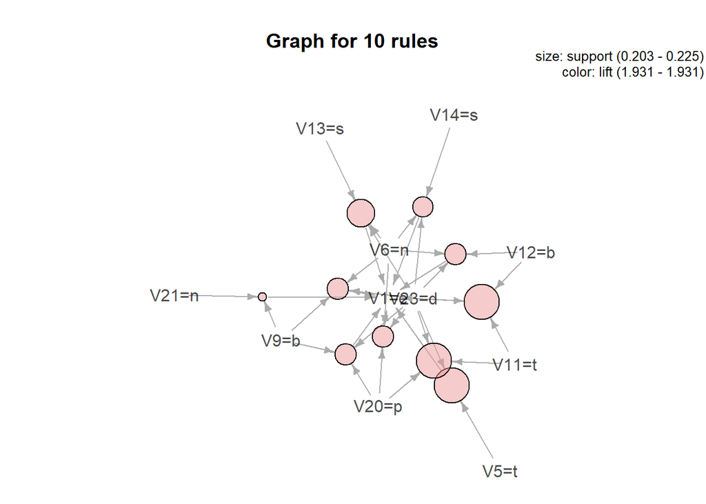

```r
plot(resultados_e_10, method="graph")
```

Setas venenosas:

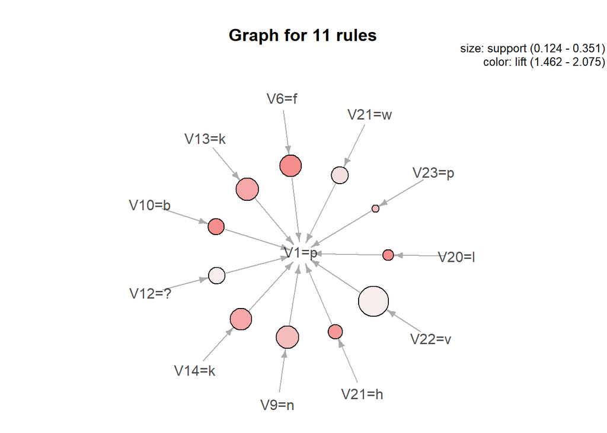

```r
plot(resultados_p, method="graph")
```